# Aging in the Northern Border Region – Applied Data Science & Visualization

Residents age 65+

21.2%

U.S.: 17.2%

Change since 2015–2019

+2.3 pts

U.S.: +1.6 pts

Nursing homes in the region

226

24,687 certified beds

Beds per 1,000 residents 65+

27.1

U.S.: 27.2

Share of residents 65+ by county, with nursing homes (circle area = beds)

[interactive chart not shown]

Bottom line

**The Northern Border region is older than the country and getting older faster. The oldest counties tend to have the fewest nursing home beds per senior.**

**Older.** 21.2% of the region’s residents are 65 or older, compared with 17.2% nationally. 61 of the 63 NBRC counties are above the national share.

**Aging faster.** Since 2015–2019, the region’s 65+ share rose 2.3 points, against 1.6 points for the U.S.

**Care is thinnest where need is highest.** Counties with a larger 65+ share have fewer nursing home beds per 1,000 seniors (correlation of -0.42). 5 counties have no certified nursing home at all.

**How to use this map.** Hover over a county or a circle for its name and click for details. Use the box in the top right to turn the nursing homes off.

Every NBRC county got older between 2015–2019 and 2020–2024

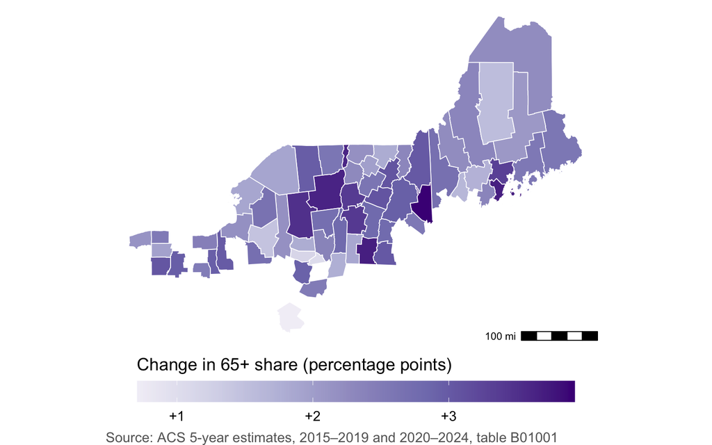

The 15 oldest counties, then and now

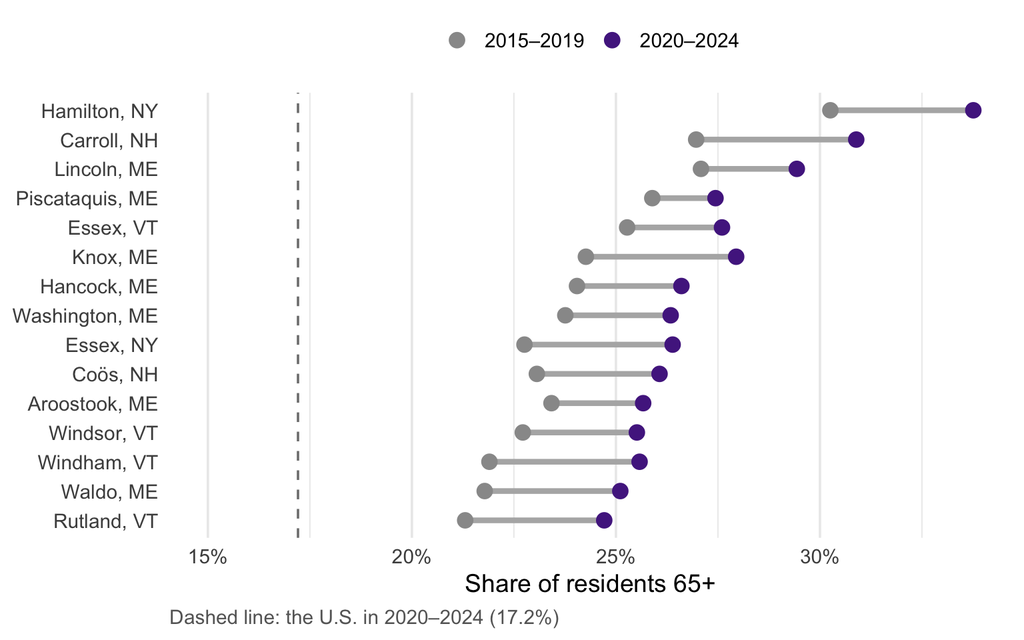

Median nursing staff turnover

48.8%

U.S.: 44.7%

Homes with a 1-star CMS rating

27%

U.S.: 19%

Nurse staff hours per resident per day (median)

3.79

U.S.: 3.71

Older counties have fewer nursing home beds per senior

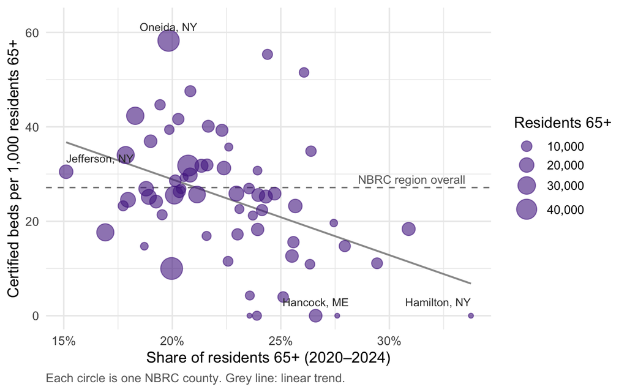

NBRC nursing homes skew toward lower CMS star ratings

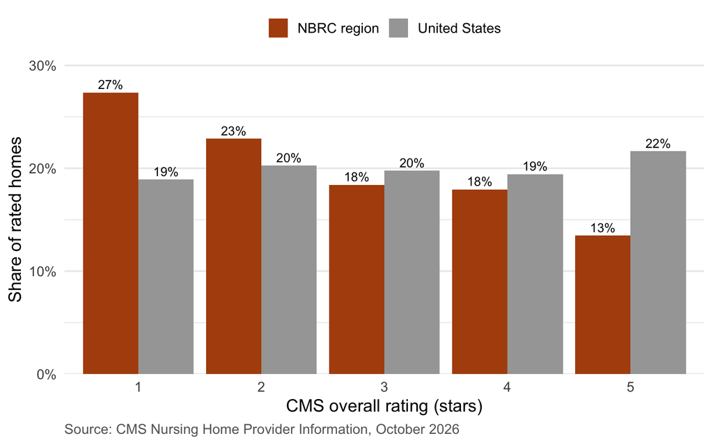

Every certified nursing home in NBRC counties (search, sort, or filter)

| Name | Town | State | Beds | Avg. residents | Rating | Staff turnover (%) | Ownership |
| --- | --- | --- | --- | --- | --- | --- | --- |
| Clover Health Care | Auburn | ME | 109 | 97.4 | ★ | 58.5 | For profit - Limited Liability company |
| Odd Fellows Health Care Center | Auburn | ME | 26 | 24.6 | ★★★ | NA | Non profit - Corporation |
| Mainegeneral Rehab & Long Term Care - Gray Birch | Augusta | ME | 77 | 69.4 | ★★★ | 45.1 | Non profit - Corporation |
| Augusta Center For Health & Rehabilitation, Llc | Augusta | ME | 72 | 67.8 | ★★★ | 35.8 | For profit - Corporation |
| Maine Veterans Home - Augusta | Augusta | ME | 108 | 103.3 | ★★★★★ | 33.2 | Non profit - Corporation |
| Mainegeneral Rehab & Long Term Care - Glenridge | Augusta | ME | 125 | 122.4 | ★★★ | 30.8 | Non profit - Corporation |
| Bangor Nursing & Rehabilitation Center | Bangor | ME | 60 | 53.6 | ★ | 60.9 | Non profit - Corporation |
| Ross Manor | Bangor | ME | 103 | 96.1 | ★★★ | 29 | For profit - Corporation |
| Westgate Center For Rehab & Alzheimer Care | Bangor | ME | 65 | 62.4 | ★★★★★ | 29.2 | For profit - Limited Liability company |
| Eastside Center For Health & Rehabilitation, Llc | Bangor | ME | 69 | 62.7 | ★★ | 40 | For profit - Limited Liability company |

[output cut: 216 more lines]

Sources and methods

**Population.** American Community Survey 5-year estimates (2015–2019 and 2020–2024), table B01001 (Sex by Age), pulled with `tidycensus`. “65+” adds up the twelve age-and-sex lines for 65 and older. Regional shares add up counts across counties first and then divide, rather than averaging county percentages.

**Nursing homes.** CMS Nursing Home Provider Information, October 2026 release. It covers Medicare- and Medicaid-certified nursing homes only, so assisted living and residential care are not in these counts. Each home was placed in a county with a spatial join (`st_join()`) on its CMS coordinates. One Amsterdam, NY home that CMS lists in Montgomery County falls just inside Fulton County this way; both are NBRC counties.

**Region.** The 63 NBRC counties in Maine, New Hampshire, New York, and Vermont. County shapes are 2024 Census cartographic boundary files (`tigris`, `cb = TRUE`).

**Caveats.** ACS figures are estimates with margins of error, which are widest for the smallest counties (Hamilton County, NY has fewer than 2,000 residents 65+). Beds per 1,000 seniors ignores people crossing county lines for care, so a county with no home may be served by a neighbor.

**Code.** Every number in this dashboard is computed in its source file. Use the `</>` button in the top right to read it.